# Analysis of fragmented river systems

2026-03-04

## What we will cover in this presentation

- River systems as networks.
- The topology of river networks.
- The `igraph` package for graph manipulation and centrality metrics calculation in R.
- Processing of geographic data to generate river networks with and without dams.
- Most of the information is covered already in the [riverconn tutorial](https://damianobaldan.github.io/riverconn_tutorial/).

## River systems as networks

- River systems can be represented as graphs/networks.
- Nodes (vertices) represent river segments.
- Links (edges) represent the connections (confluences and barriers) between segments.
- Many connectivity indices are defined for graphs, straightforward application to river systems when represented as graphs.
- Inclusion of barriers complicates the representation, but several indices can be adapted to account for them (e.g. DCI, Dendritic Connectivity Index).

## The topology of river networks

- Planar networks: no links (edges) intersections.
- Tree-like networks: no loops, only one path between any two nodes (vertices).
- Number of nodes (vertices) and links (edges) in a tree-like network: E = V - 1.
- Weighted networks: node weights can represent attributes of river segments (e.g. length, discharge, etc.), edge weights can represent the strength of the connection (e.g. presence/absence of a barrier, etc.).

## Which packages we will use

- `sf` and `terra` for vector and raster data manipulation
- `dplyr` for data manipulation: helps building pipelines for easy-to-read data manipulation (loaded with the `tidyverse`)
- `ggplot2` for data visualization: a bit painful, but easily integrates `sf` and `terra` objects for plotting (loaded with the `tidyverse`)
- `igraph` for graph manipulation: useful for building/editing/managing graphs

## Which packages we will use

```r
library(tidyverse)
library(sf)
library(terra)
library(tidyterra)
library(viridis)
library(igraph)
```

## The `igraph` package

## The `igraph` package

- The `igraph` package implements routines for graphs and network analysis.
- It can handle large graphs very well and provides functions for generating random and regular graphs, graph visualization, centrality methods and much more.
- The packages allows for easy construction of igraph objects based on symbolic description of edges and vertices, edges and vertices lists, or adjacency matrices.
- The book [Statistical Analysis of Network Data with R by Kolaczyk and Csardi (2014)](https://link.springer.com/book/10.1007/978-3-030-44129-6#toc) offers a comprehensive tutorial on the possibilities offered by the igraph package, including network data manipulation and visualization, descriptive analysis of network graphs, mathematical and statistical modeling of graphs, and network topology inference.

## The `igraph` package

We build a graph using a symbolic representation of vertices and edges. The notation 1–2 means that there is an edge between vertices 1 and 2.

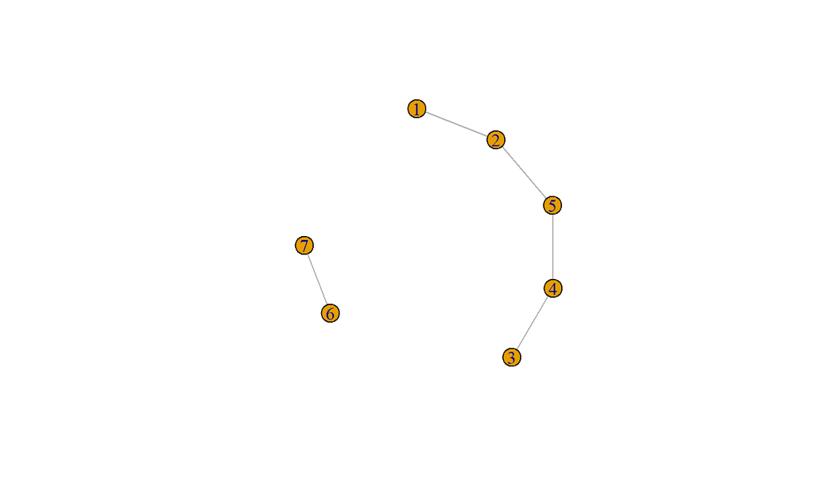

```r
g <- igraph::graph_from_literal(1--2, 2--5, 3--4, 4--5, 6--7)
plot(g)
```

## The `igraph` package

We check the graph. The graph has 7 vertices and 5 edged and is undirected (UN). The graph has the attribute name, that is a vertex attribute of class character. The graph has no edge attributes.

```r
g
```

```
## IGRAPH a9b9f1f UN-- 7 5 --
## + attr: name (v/c)
## + edges from a9b9f1f (vertex names):
## [1] 1--2 2--5 5--4 3--4 6--7
```

## The `igraph` package

We build a directed graph using a symbolic representation of vertices and edges. The notation 1-+2 means that there is an edge with direction from 1 and 2.

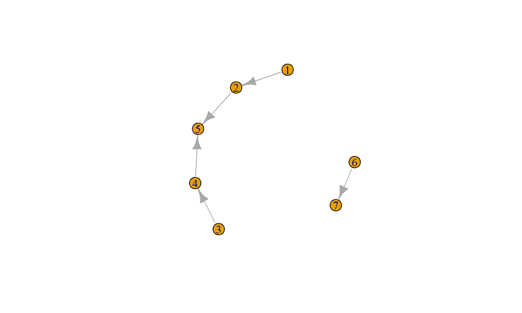

```r
g <- igraph::graph_from_literal(1-+2, 2-+5, 3-+4, 4-+5, 6-+7)
plot(g)
```

## The `igraph` package

We check the graph. The graph has 7 vertices and 5 edged and is directed (DN). The graph has the attribute name, that is a vertex attribute of class character. The graph has no edge attributes.

```r
g
```

```
## IGRAPH a9c3a75 DN-- 7 5 --
## + attr: name (v/c)
## + edges from a9c3a75 (vertex names):
## [1] 1->2 2->5 3->4 4->5 6->7
```

## The `igraph` package

We create a graph that is a bit more complex.

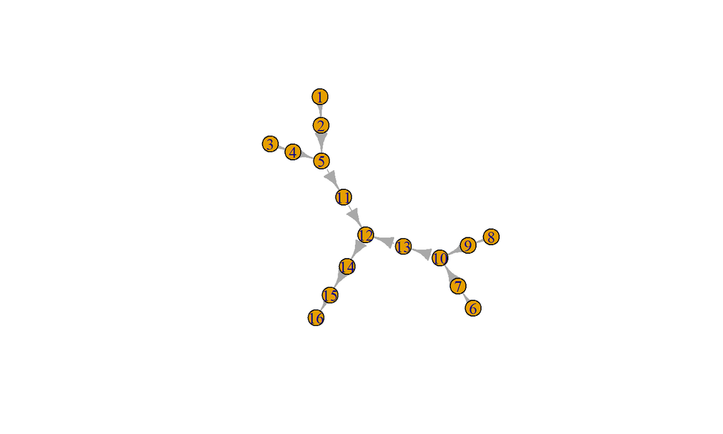

```r
g <- igraph::graph_from_literal( 1-+2, 2-+5, 3-+4, 4-+5, 6-+7,
  7-+10, 8-+9, 9-+10, 5-+11, 11-+12, 10-+13, 13-+12, 12-+14, 14-+15, 15-+16)
plot(g)
```

## The `igraph` package

We can transform this graph to an adjacenty matrix (`as_adjacency_matrix()`; 1 = there is an edge). Note that the matrix is not symmetric because the graph is directed.

```r
mat <- igraph::as_adjacency_matrix(g)
mat[1:8, 1:8]
```

```
## 8 x 8 sparse Matrix of class "dgCMatrix"
##    1 2 5 3 4 6 7 10
## 1  . 1 . . . . .  .
## 2  . . 1 . . . .  .
## 5  . . . . . . .  .
## 3  . . . . 1 . .  .
## 4  . . 1 . . . .  .
## 6  . . . . . . 1  .
## 7  . . . . . . .  1
## 10 . . . . . . .  .
```

## The `igraph` package

The graph can be generated back from the adjacency matrix (`graph_from_adjacency_matrix()`). We check if the new graph is isomorphic (`isomorphic` function) to the original one (i.e. they are the same graph, but with different vertex labels).

```r
g1 <- igraph::graph_from_adjacency_matrix(mat)
igraph::isomorphic(g1, g)
```

```
## [1] TRUE
```

## The `igraph` package

We can transform this graph to a data.frame (`as_data_frame()`). Note that the data.frame has two columns, `from` and `to`, that represent the source and target vertices of each edge.

```r
g_df <- igraph::as_data_frame(g, "edges")
head(g_df)
```

```
##   from to
## 1    1  2
## 2    2  5
## 3    5 11
## 4    3  4
## 5    4  5
## 6    6  7
```

## The `igraph` package

The graph can be generated back from the data.frame (`graph_from_data_frame()`). We check if the new graph is isomorphic (`isomorphic`) to the original one (i.e. they are the same graph, but with different vertex labels).

```r
g1 <- igraph::graph_from_data_frame(g_df)
igraph::isomorphic(g1, g)
```

```
## [1] TRUE
```

## Centrality metrics with the `igraph` package

## Centrality metrics with the `igraph` package

- Centrality metrics are used to identify the most important vertices in a graph.
- Identify nodes that are relevant for connecting separate sections of the graph.
- Degree centrality: number of edges connected to a vertex (for weighted networks: strenght).
- Betweenness centrality: number of shortest paths that pass through a vertex.
- Closeness (harmonic) centrality: inverse of the average shortest path length from a vertex.
- For directed and undirected graphs.

## Centrality metrics with the `igraph` package

Degree centrality of node \(i\) (\(k_{i}\)): number of edges connected to a vertex (for weighted networks: strenght)

\[k_i = \sum_{j}a_{ij}\] where \(a_{ij}\) is the element of the adjacency matrix that represents the presence (1) or absence (0) of an edge between vertices \(i\) and \(j\)

## Centrality metrics with the `igraph` package

Betweenness centrality: number of shortest paths that pass through a vertex

\[g_i = \sum_{s \neq i \neq t} \frac{\sigma_{st}(i)}{\sigma_{st}} \] where where \(\sigma_{st}\) is the total number of shortest paths from node \(s\) to node \(t\) and \(\sigma_{st}(i)\) is the number of those paths that pass through node \(i\) (not where \(i\) is an endpoint)

## Centrality metrics with the `igraph` package

Closeness centrality: inverse of the average shortest path length from a vertex

\[c_i = \frac{1}{\sum_{j \neq i} {d(ij)}} \] Harmonic centrality: for disconnected graphs (to avoid issues with \(d(ij) = \infty\))

\[c_i = \sum_{j \neq i} \frac{1}{ {d(ij)}} \]

where \(d(ij)\) is the shortest distance between nodes \(i\) and \(j\)

## Centrality metrics with the `igraph` package

We create a graph, calculate degree, betweeness and closeness centrality and store the values as nodes attributes

```r
g <- igraph::graph_from_literal( 1-+2, 2-+5, 3-+4, 4-+5, 6-+7,
  7-+10, 8-+9, 9-+10, 5-+11, 11-+12, 10-+13, 13-+12, 12-+14, 14-+15, 15-+16)
V(g)$degree <- igraph::degree(g)
V(g)$betweenness <- igraph::betweenness(g)
V(g)$closeness <- igraph::closeness(g, mode = "all")
g
```

```
## IGRAPH aa1c7c3 DN-- 16 15 --
## + attr: name (v/c), degree (v/n), betweenness (v/n), closeness (v/n)
## + edges from aa1c7c3 (vertex names):
##  [1] 1 ->2  2 ->5  5 ->11 3 ->4  4 ->5  6 ->7  7 ->10 10->13 8 ->9  9 ->10
## [11] 11->12 12->14 13->12 14->15 15->16
```

## Centrality metrics with the `igraph` package

We plot the graph with vertex color proportional to the centrality metrics

```r
library(ggnetwork)
gg0 <- ggnetwork(g)

pl1 <- ggplot(gg0, aes(x = x, y = y, xend = xend, yend = yend)) +
  geom_edges(arrow = arrow(length = unit(0.5, "lines"), type = "closed")) +
  geom_nodes(aes(color = degree), size = 5) + theme_void()

pl2 <- ggplot(gg0, aes(x = x, y = y, xend = xend, yend = yend)) +
  geom_edges(arrow = arrow(length = unit(0.5, "lines"), type = "closed")) +
  geom_nodes(aes(color = closeness), size = 5) + theme_void()

pl3 <- ggplot(gg0, aes(x = x, y = y, xend = xend, yend = yend)) +
  geom_edges(arrow = arrow(length = unit(0.5, "lines"), type = "closed")) +
  geom_nodes(aes(color = betweenness), size = 5) + theme_void()

plot <- ggpubr::ggarrange(pl1, pl2, pl3, ncol = 3, nrow = 1)
```

## Centrality metrics with the `igraph` package

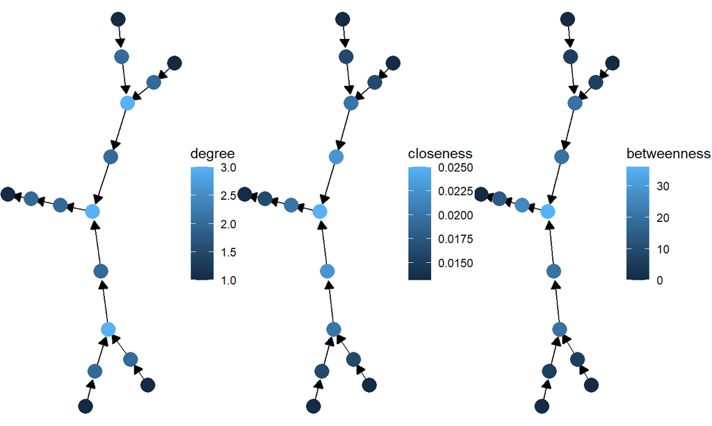

## The Ebro case study

## The Ebro case study

Based on the geographyc data that were retrieved in the previous lecture, we would like to build a graph representation of the Ebro river network. In this representation:

- vertices are river segments.
- edges are confluences or dams.

## The Ebro case study

We load the input data in the environment. We have three shapefiles: one for the river network, one for the river basin and one for the dams. The dams are from a local dataset, that contains also informations on the upstream reservoir.

```r
shape_river <- "data/HydroRIVERS_sample/sample__hydroRIVERS_v10_eu.shp" %>%
  st_read(quiet = TRUE)
shape_basin <- "data/HydroBASINS_sample/sample__hybas_eu_lev10_v1c.shp" %>%
  st_read(quiet = TRUE)
shape_dams <- "data/dams_ebro/embalses.shp" %>%
  st_read(quiet = TRUE)
```

Then, we load the content of the file `functions_network_creation.R`, that contains several useful functions.

```r
source("functions_network_creation.R")
```

## The Ebro case study

```r
shape_river_small <- shape_river %>%
  filter(UPLAND_SKM > 80)

nrow(shape_river)
```

```
## [1] 4980
```

```r
nrow(shape_river_small)
```

```
## [1] 1870
```

## The Ebro case study

We convert the dams shapefile from polygons to points (the polygons are the borders of the reservoir).

```r
dams_to_points <- shape_dams %>%
  st_as_sf() %>% st_centroid() %>%
  mutate(id = 1:nrow(.)) %>%  dplyr::select(id) %>%
  st_transform(crs = "+proj=longlat +datum=WGS84")

plot <- ggplot() +
  coord_fixed() +
  theme_minimal() +
  ggspatial::layer_spatial(shape_basin, fill = "white", color = "gray90") +
  ggspatial::layer_spatial(shape_river_small, aes(color = log10(UPLAND_SKM)) )+
  ggspatial::layer_spatial(dams_to_points) +
  scale_color_viridis(direction = -1, name= "upstream area \n(log10[Km^2])") +
  theme(legend.position = "bottom") +
  labs(caption = "Black dots are the position of the dams")
```

## The Ebro case study

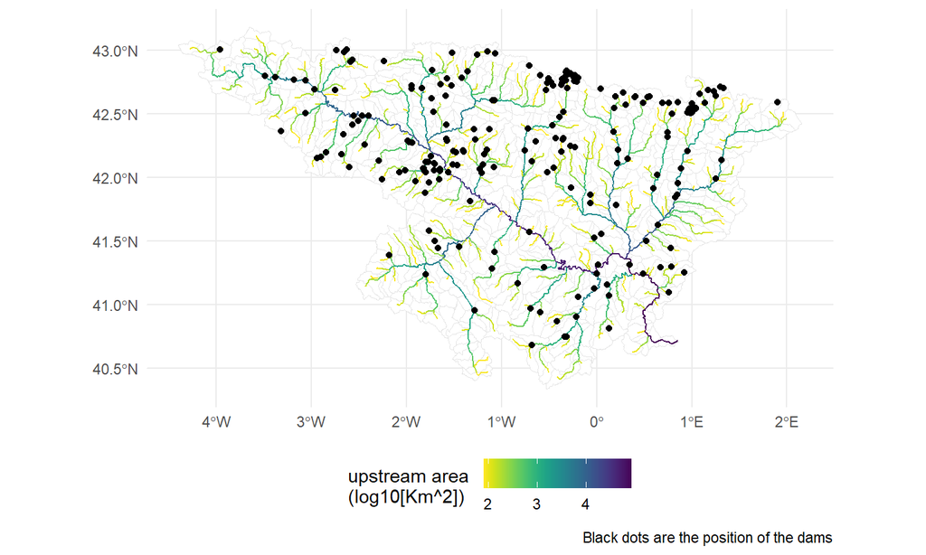

## Hydrographic data processing

## Hydrographic data processing

The first step before building the graph is to identify confluences. To do this, the river network is split into the smallest segments allowed by its geometry.

```r
shape_river_simple <- shape_river_small %>%
  st_as_sf %>%
  st_union()

river_to_points <- shape_river_simple  %>%
  st_as_sf() %>%
  st_cast("POINT") %>%
  mutate(id = 1:nrow(.))
```

## Hydrographic data processing

Confluences are the points where three or more segments overlap.

```r
joins_selection <- river_to_points %>%
  st_equals() %>%
  Filter(function(x){length(x) > 2}, .) %>%
  lapply(., FUN = min) %>%
  unlist() %>%
  unique()

river_joins <- river_to_points %>%
  filter(id %in% joins_selection)
```

## Hydrographic data processing

Finally, the simplified shapefile is split where conferences are.

```r
shape_river_simplified <- lwgeom::st_split(shape_river_simple, river_joins) %>%
  st_collection_extract(.,"LINESTRING") %>%
  data.frame(id = 1:length(.), geometry = .) %>%
  st_as_sf() %>%
  mutate(length = st_length(.))
```

## Hydrographic data processing

We plot to make sure everything was succesful.

```r
plot <- ggplot() +
  coord_fixed() +
  ggspatial::layer_spatial(shape_river_simplified, aes(color = id))+
  scale_color_viridis(direction = -1, name= "Reach ID") +
  ggspatial::layer_spatial(river_joins, shape = 1)+
  theme_minimal() +
  theme(legend.position = "bottom")+
  labs(caption = "Hollow points are the position of the junctions")
```

## Hydrographic data processing

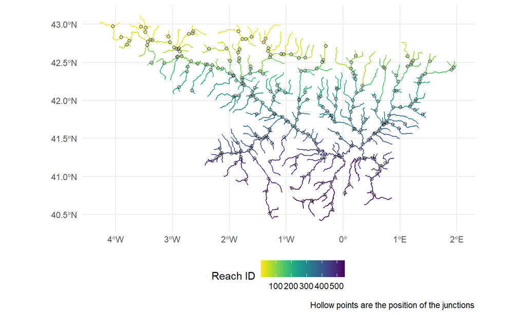

## Barriers data processing

## Barriers data processing

We use the custom `snap_to_river()` function to overlay dams with the river network. we use `st_distance()` to make sure the snapped dams are overlapping with the river network.

```r
dams_snapped <- snap_to_river(dams_to_points,
                              shape_river_simple %>% st_sf(),
                              max_dist = 1000)

dams_snapped_reduced <- dams_snapped[
    st_contains(shape_river_simple %>% st_sf(),
                dams_snapped, prepared = FALSE)[[1]],]

st_distance(dams_snapped_reduced, shape_river_simple) %>% sum
```

```
## 0 [m]
```

## Barriers data processing

If two or more dams are snapped to the same point, they are considered as one dam.

```r
dams_snapped_reduced_joined <- dams_snapped_reduced %>%
  mutate(cluster =
           st_equals(dams_snapped_reduced, dams_snapped_reduced) %>%
           sapply(., FUN = function(x) paste0(x, collapse = "_"))) %>%
  group_by(cluster) %>%
  slice(1) %>%
  ungroup() %>%
  mutate(id_dam = as.character(1:nrow(.)), pass_u = 0.1, pass_d = 0.8) %>%
  as.data.frame %>%
  st_as_sf() %>%
  st_join(., shape_river_small, join = st_is_within_distance, dist = 10 ) %>%
  group_by(id) %>%
  slice(which.max(UPLAND_SKM)) %>%
  ungroup()
```

## Barriers data processing

The custom function `headwaters_dam()` is useful for identifying dams that do not have an upstream reach and would not be contributing to fragmentation.

```r
headwaters_checking <- headwaters_dam(dams_snapped_reduced_joined, shape_river_simple)

headwaters_checking$flag_headwater %>% sum()
```

```
## [1] 0
```

## Barriers data processing

Now dams can be plotted.

```r
plot <- ggplot() +
  coord_fixed() +
  ggspatial::layer_spatial(shape_river_simple, color = "gray70")+
  ggspatial::layer_spatial(dams_snapped_reduced, shape = 1) +
  theme_minimal() +
  theme(legend.position = "bottom")+
  ggspatial::annotation_north_arrow(location = "br")+
  ggspatial::annotation_scale(location = "bl", style = "ticks") +
  labs(caption = "Hollow points are the position of the dams")
```

## Barriers data processing

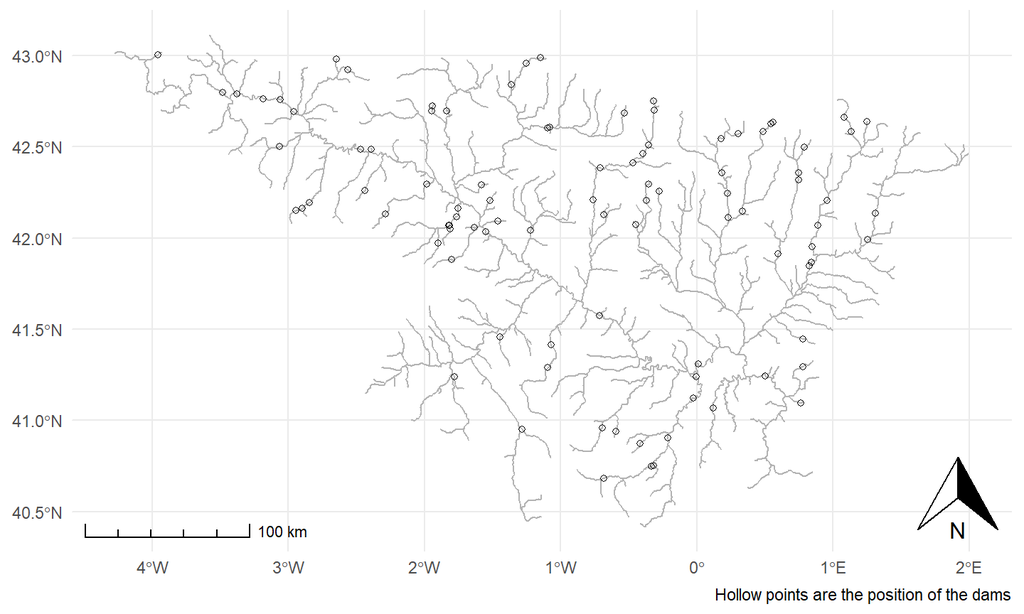

## Integrating hydrographic and dams data

## Integrating hydrographic and dams data

The position of confluences and dams are integrated in the same data.frame, that will be used to build the graph. The type of link (confluence or dam) is stored in the column `type`, while the columns `pass_u` and `pass_d` store the passability values for upstream and downstream movement, respectively.

```r
network_links <- rbind(
  dams_snapped_reduced_joined %>%
    mutate(type = "dam", id_barrier = id_dam) %>%
    dplyr::select(type, id_barrier, pass_u, pass_d),
  river_joins %>% mutate(type = "joint") %>%
    dplyr::select(type) %>%
    mutate(id_barrier = NA, pass_u = NA, pass_d = NA) %>%
    rename(geometry = x)) %>%
  mutate(id_links = 1:nrow(.))

network_links %>%
  st_write("data/dams_ebro/network_links.shp", delete_dsn = TRUE)
```

```
## Deleting source `data/dams_ebro/network_links.shp' using driver `ESRI Shapefile'
## Writing layer `network_links' to data source
##   `data/dams_ebro/network_links.shp' using driver `ESRI Shapefile'
## Writing 370 features with 5 fields and geometry type Point.
```

## Integrating hydrographic and dams data

Finally, the shapefile is sliced based on confluences and dams positions.

```r
river_net_simplified <- lwgeom::st_split(shape_river_simple, network_links) %>%
  st_collection_extract(.,"LINESTRING") %>%
  data.frame(NodeID = 1:length(.), geometry = .) %>%
  st_as_sf() %>%
  mutate(length = st_length(.)) %>%
  st_join(., shape_river_small, join = st_is_within_distance, dist = 0.01 ) %>%
  group_by(NodeID) %>%
  slice(which.max(UPLAND_SKM)) %>%
  ungroup()
```

## Integrating hydrographic and dams data

We check with a plot. The visualized points will be the river graph edges.

```r
plot <- ggplot() +
  coord_fixed() +
  ggspatial::layer_spatial(river_net_simplified, color = "gray70")+
  ggspatial::layer_spatial(network_links, aes(shape = type))+
  scale_shape_manual(name = "Splitting points", values=c("dam" =17,"joint" = 23))+
  theme_minimal() +
  ggspatial::annotation_scale(location = "bl", style = "ticks")
```

## Integrating hydrographic and dams data

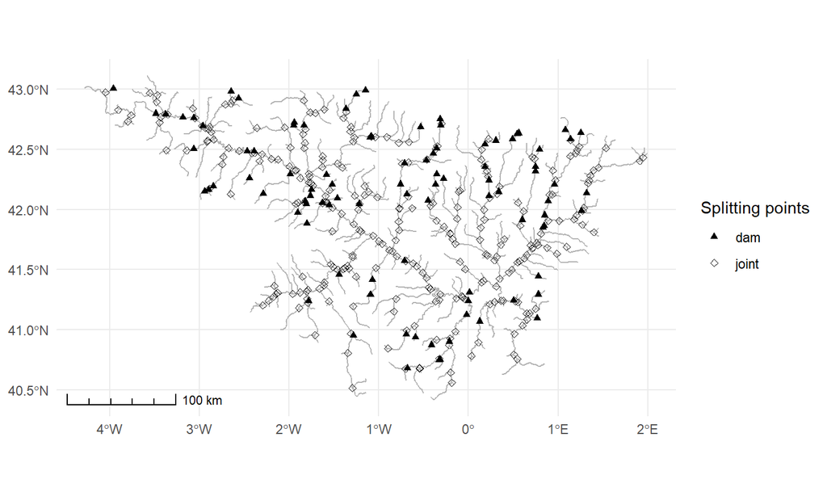

## Integrating hydrographic and dams data

One last step: we extract the elevation for each river segment (its centroid) using the same workflow as in the previous lecture.

```r
elevation <- elevatr::get_elev_raster(shape_basin, z = 8)

reach_centroids <- river_net_simplified %>%
  st_as_sf() %>%
  st_centroid()

river_net_simplified$elevation <- elevation %>%
  terra::extract(reach_centroids)
```

## Troubleshooting

## Troubleshooting

A common issue when generating the river network is when more than three segments are overlapping in a confluence. The custom function `multiple_confluences()` returns a shapefile that flags problematic confluences.

```r
confluences <- multiple_confluences(river_net_simplified)
confluences[1:5,]
```

```
## Simple feature collection with 5 features and 3 fields
## Geometry type: POINT
## Dimension:     XY
## Bounding box:  xmin: -4.047917 ymin: 42.81042 xmax: -1.364583 ymax: 42.97292
## Geodetic CRS:  WGS 84
## # A tibble: 5 × 4
##   NodeID             geometry n_confluences flag_confluences
##    <int>          <POINT [°]>         <int> <lgl>
## 1      1  (-3.46875 42.95208)             3 FALSE
## 2      2 (-4.047917 42.97292)             3 FALSE
## 3      5 (-3.552083 42.96875)             3 FALSE
## 4      7 (-1.364583 42.81042)             3 FALSE
## 5     10 (-1.835417 42.90625)             3 FALSE
```

```r
sum(confluences$flag_confluence)
```

```
## [1] 0
```

## Troubleshooting

```r
shp_check <- check_components(network_links, river_net_simplified)
shp_check$component %>% table()
```

```
## .
##   1
## 646
```

We see that there is only one component. This is not surprising because the file was already corrected.

## Troubleshooting

```r
example_broken <- st_read("data/example_broken_river/example_broken.shp", quiet = TRUE)

shp_check <- check_components(network_links, example_broken)
shp_check$component %>% table()
```

```
## .
##   1   2   3   4   5   6
## 644   3   1   1   1   1
```

## Troubleshooting

We check where the shapefile is broken in a plot.

```r
plot <- ggplot() +
  coord_fixed() +
  ggspatial::layer_spatial(shp_check, aes(color = as.factor(component)))+
  theme_minimal() +
  theme(legend.position = "bottom")
```

## Troubleshooting

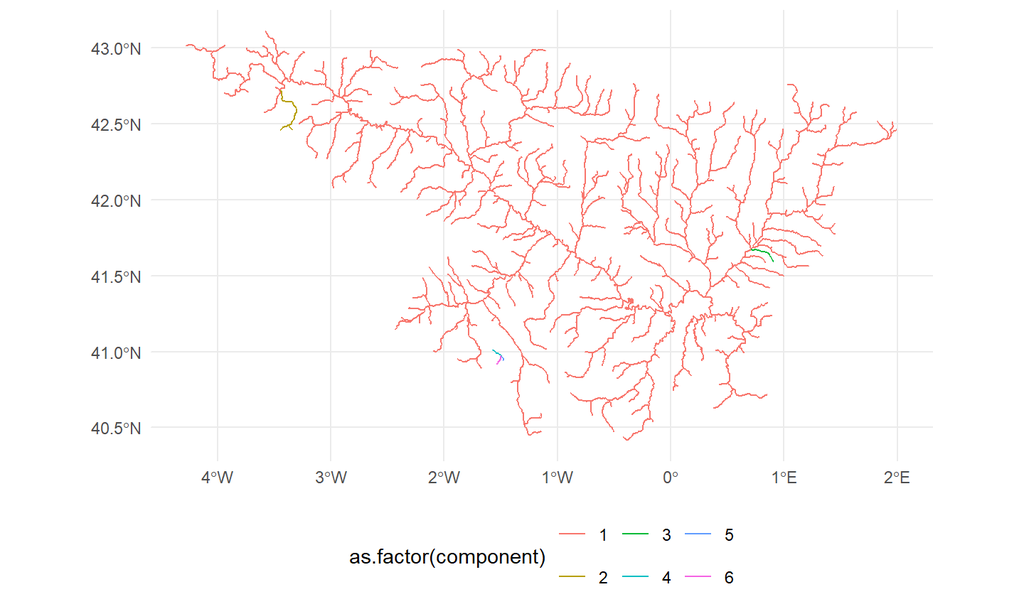

## Creation of the igraph object

## Creation of the igraph object

```r
outlet <- river_net_simplified$NodeID[river_net_simplified$DIST_DN_KM == 0 ]

river_graph <- create_network(network_links, river_net_simplified, outlet)

river_graph %>%
  saveRDS("data/river_graph/river_graph.rds")

river_net_simplified %>%
  st_write("data/river_graph/river_net_simplified.shp", delete_dsn = TRUE, quiet = TRUE)
```

## Creation of the igraph object

We check the created igraph object

```r
river_graph
```

```
## IGRAPH be8e943 DN-- 646 645 --
## + attr: name (v/n), length (v/n), HYRIV_ID (v/n), NEXT_DOWN (v/n),
## | MAIN_RIV (v/n), LENGTH_KM (v/n), DIST_DN_KM (v/n), DIST_UP_KM (v/n),
## | CATCH_SKM (v/n), UPLAND_SKM (v/n), ENDORHEIC (v/n), DIS_AV_CMS (v/n),
## | ORD_STRA (v/n), ORD_CLAS (v/n), ORD_FLOW (v/n), HYBAS_L12 (v/n),
## | elevation (v/n), type (e/c), id_links (e/n), id_barrier (e/c), pass_u
## | (e/n), pass_d (e/n)
## + edges from be8e943 (vertex names):
##  [1] 515->516 520->516 519->520 496->520 276->160 153->160 160->164 162->161
##  [9] 161->164 642->640 646->640 641->643 645->643 638->635 640->635 636->629
## [17] 644->629 632->631 639->631 629->628 631->630 630->628 628->627 627->624
## + ... omitted several edges
```

## Creation of the igraph object

We check the created igraph object

```r
igraph::get.edge.attribute(river_graph) %>% names
```

```
## [1] "type"       "id_links"   "id_barrier" "pass_u"     "pass_d"
```

```r
igraph::get.vertex.attribute(river_graph) %>% names
```

```
##  [1] "name"       "length"     "HYRIV_ID"   "NEXT_DOWN"  "MAIN_RIV"
##  [6] "LENGTH_KM"  "DIST_DN_KM" "DIST_UP_KM" "CATCH_SKM"  "UPLAND_SKM"
## [11] "ENDORHEIC"  "DIS_AV_CMS" "ORD_STRA"   "ORD_CLAS"   "ORD_FLOW"
## [16] "HYBAS_L12"  "elevation"
```

## Creation of the igraph object

We edit the length attribute of the graph. and we turn the name attribute to character.

```r
V(river_graph)$length <- V(river_graph)$length / 10000
V(river_graph)$name <- as.character(V(river_graph)$name)
```

## Alternative ways of creating the graph

## Alternative ways of creating the graph

- Both the HydroBASINS and the HydroRIVERS have a built-in graph structure (fields NEXT_DOWN) that can be used to create the graph.
- This structure does not account for the presence of dams.
- It could be nevertheless useful for large scale analyses where only dams in the main channel of the subcatchment are considered.
- Sometmes we work with hydrographic data that are not as ‘clean’ as HydroSHEDS.

## Centrality metrics calculation

## Centrality metrics calculation

We calculate betweeness and closeness centrality and store the values as nodes attributes

```r
V(river_graph)$btw <- igraph::betweenness(river_graph)
V(river_graph)$cc_dir <- igraph::closeness(river_graph, mode = "out")
V(river_graph)$cc <- igraph::closeness(river_graph, mode = "all")
```

## Centrality metrics calculation

We can plot the centrality metrics. We create a dataframe with all the vertices attributes and join it with the river shapefile for the plotting.

```r
df_river_graph_v <- igraph::as_data_frame(river_graph, what = "vertices") %>%
  dplyr::mutate(NodeID = as.numeric(name)) %>%
  dplyr::select(-length)

river_plot <- river_net_simplified %>%
  left_join(df_river_graph_v)

plot <- ggplot() +
    coord_fixed() + theme_void()+
    ggspatial::layer_spatial(river_plot, aes(color = log10(btw + 1)))+
    scale_color_viridis(name = "Bewteenness (log10)")+
    theme(legend.position = "bottom")
```

## Centrality metrics calculation

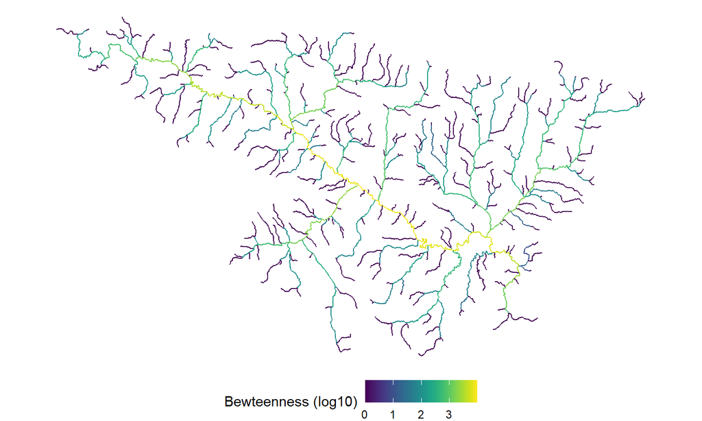

## Centrality metrics calculation

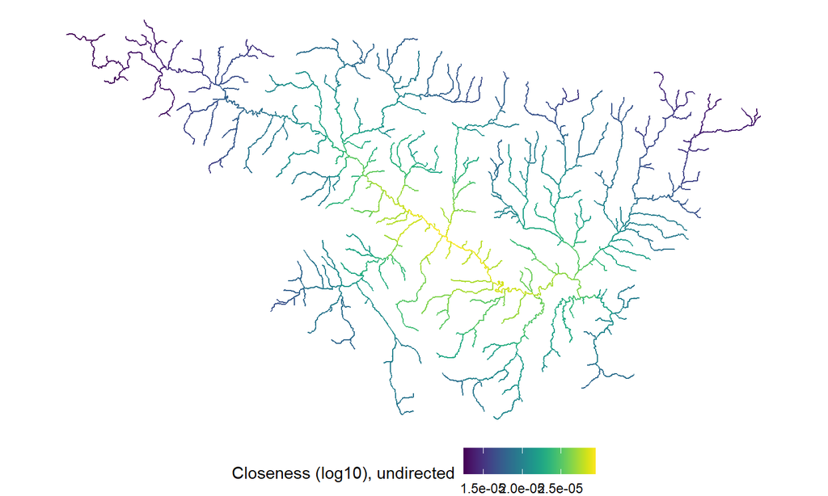

## Centrality metrics calculation

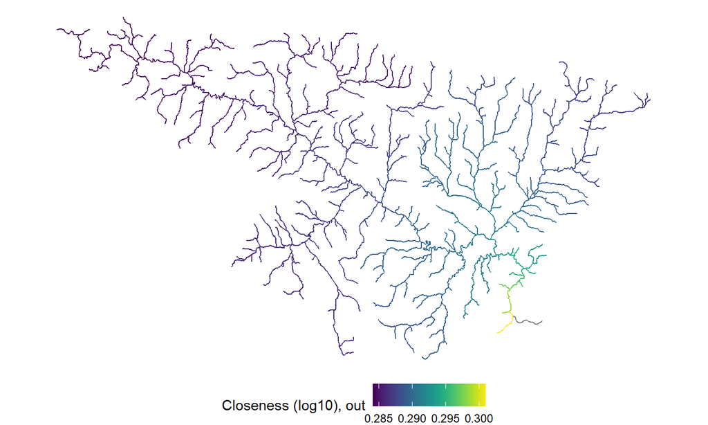